# CIND 123 - Data Analytics: Basic Methods

# Assignment 1 (10%)

## Instructions

Use RStudio for this assignment. Complete the assignment by inserting your R code wherever you see the string “#INSERT YOUR ANSWER HERE”.

Submit **both** the rmd and generated output files. Failing to submit both files will be subject to mark deduction.

## Sample Question and Solution

Use `seq()` to create the vector $(1,2,3,\ldots,10)$.

```r
seq(1,10)
```

```
##  [1]  1  2  3  4  5  6  7  8  9 10
```

## Question 1

1. Use the `seq()` function to create the vector $(1, 7, 13, \ldots, 61)$. Note that each term in this sequence is of the form $1 + 6n$ where $n = 0, \ldots, 10$.

```r
seq(1,61,6)
```

```
##  [1]  1  7 13 19 25 31 37 43 49 55 61
```

2. Use `rep()` to create the vector $(2,3,4,\dots,2,3,4, \dots,2,3,4)$ in which the sequence $(2,3,4)$ is repeated 5 times.

```r
rep(2:4,5)
```

```
##  [1] 2 3 4 2 3 4 2 3 4 2 3 4 2 3 4
```

3. To convert factor to number, would it be correct to use the following commands? Explain your answer.

`factorVar <- factor(c(1, 6, 5.4, 3.2));as.numeric(factorVar)`

```r
factorVar <- factor(c(1, 6, 5.4, 3.2))
as.numeric(factorVar)
```

```
## [1] 1 4 3 2
```

```r
class(factorVar)
```

```
## [1] "factor"
```

```r
#I would say it is not correct because it does not return the original value. as.numeric(factorVar) returns the number that R assigns to the level of factorVar. I would use as.numeric(as.character(factorVar)) instead.
```

4. A comma-separated values file `dataset.csv` consists of missing values represented by question marks (`?`) and exclamation mark (`!`). How can you read this type of files in R?

```r
#read.csv('dataset.csv', na.strings = c('?','!'))
```

## Question 2

1. Compute:
   $$\sum_{n=10}^{100} n^3$$

```r
sum((10:100)^3)
```

```
## [1] 25500475
```

2. Compute:
   $$\sum_{n=1}^{10}\left(\frac{2^{n}}{n^2} + \frac{n^{4}}{4^{n}}\right)$$

```r
n = 1:10
sum((2^n)/(n^2)+(n^4)/(4^n))
```

```
## [1] 35.80589
```

3. Compute:
   $$\sum_{n=0}^{10} \frac{1}{(n+1)!}$$

```r
0:10 -> n
sum (1 / factorial(n+1))
```

```
## [1] 1.718282
```

4. Compute:
   $$\prod_{n=3}^{33} \left(3n + \frac{3}{\sqrt[3]{n}}\right)$$

```r
n <- (3:33)
prod((3*n)+(3/n^(1/3)))
```

```
## [1] 9.054339e+51
```

5. Explain the output of this R-command: `c(0:5)[NA]`

```r
a<-c(0:5)
length(a) #length of this vector is 6.
```

```
## [1] 6
```

```r
#for instance c(0,5)[7] returns NA because it doesn't have the 7th value.
#There is no dimension NA, so it returns NA its length of the coordinates; therefore, it returns NA NA NA NA NA NA.
```

6. What is the difference between is.vector() and is.numeric() functions?

```r
#is.vector() returns TRUE only if the object inside the bracket is a vector or expression with no attributes apart from names.
#is.numeric() returns true if the base type of the class is double or integer, which can be represented as arithmetic operations or comparable by their base class. In other words, for any values enclosed in a vector being numeric, it returns TRUE.
```

7. List at least three advantages and three disadvantages of using `RShiny` package?

```r
###Advantages:
#1. RShiny offers an extensive visualization library. RShiny is great for more complex statistical modeling and its visualization.
#2. RShiny employs R's backend for data wrangling which has a wide variety of packages for the same.
#3. RShiny is customizable with CCS and HTML.
###Disadvantages:
#1. There is cost of maintaining an application.
#2. RShiny is not great at multi-page apps.
#3. It is difficult to use for gathering and saving data to the database.
```

## Question 3

`iris` dataset gives the measurements in centimeters of the variables sepal length, sepal width, petal length and petal width, respectively, for 50 flowers from each of 3 species of iris. The species are Iris setosa, versicolor, and virginica.

Install the `iris` dataset on your computer using the command `install.packages("datasets")`. Then, load the `datasets` package into your session using the following command.

```r
library(datasets)
```

1. Display the first six rows of the `iris` data set.

```r
head(iris)
```

```
##   Sepal.Length Sepal.Width Petal.Length Petal.Width Species
## 1          5.1         3.5          1.4         0.2  setosa
## 2          4.9         3.0          1.4         0.2  setosa
## 3          4.7         3.2          1.3         0.2  setosa
## 4          4.6         3.1          1.5         0.2  setosa
## 5          5.0         3.6          1.4         0.2  setosa
## 6          5.4         3.9          1.7         0.4  setosa
```

2. Compute the average of the first four variables (Sepal.Length, Sepal.Width, Petal.Length and Petal.Width) using `sapply()` function.

Hint: You might need to consider removing the `NA` values, otherwise the average will not be computed.

```r
sapply (iris[1:4], mean, rm=NA)
```

```
## Sepal.Length  Sepal.Width Petal.Length  Petal.Width
##     5.843333     3.057333     3.758000     1.199333
```

3. Show how to use R to replace the missing values in this dataset with plausible ones.

```r
iris[is.na(iris)] <-0
```

4. Compute the standard deviation for only the first and the third variables (Sepal.Length and Petal.Length)

```r
sd(iris[,1]) #Sepal.Length
```

```
## [1] 0.8280661
```

```r
sd(iris[,3]) #Petal.Length
```

```
## [1] 1.765298
```

5. Construct a boxplot for `Sepal.Width` variable, then display the values of all the outliers. Explain how these outliers have been calculated.

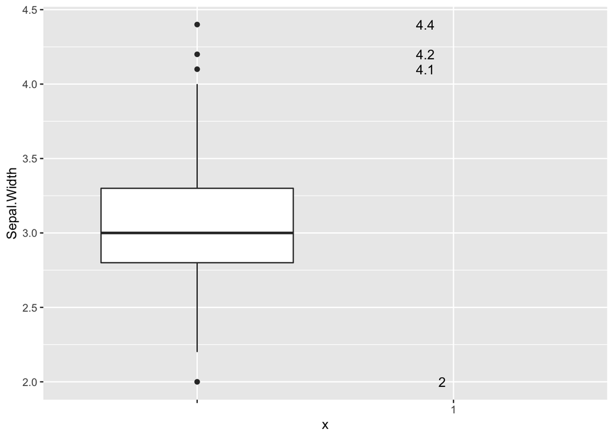

```r
library(ggplot2)

g<- ggplot(iris, aes(x= " ",y=Sepal.Width)) + geom_boxplot()

out<-ggplot_build(g)[["data"]][[1]][["outliers"]]
tidyout <- purrr::map_df(out, tibble::as_tibble, .id = "Sepal.Width")

g + geom_text(data = tidyout, aes(Sepal.Width, value, label = value), hjust =2)
```

```r
#find Q1, Q3 from summary(iris)
#The outliers that are above the upper whisker are: larger than Q3 by at least 1.5 times the interquartile range(Q3-Q1). #1.5(Q3-Q1)> Q3 #Values above  4.05, which are 4.1, 4.2, 4.4
#The outliers that are below the lower whisker are: smaller than Q1 by at least 1.5 times the interquartile range. #1.5(IQR)< Q1 #Value below 2.05, which is 2
```

6. Compute the upper quartile of the `Sepal.Width` variable with two different methods.

```r
library(dplyr)
#first method
dplyr::summarize(iris,"Lower Quartile" = quantile(Sepal.Width,0.25),"Upper Quartile" = quantile(Sepal.Width,0.75))
```

```
##   Lower Quartile Upper Quartile
## 1            2.8            3.3
```

```r
#second method
mySummary <- summary(iris$Sepal.Width)
dplyr::summarize(iris,"Lower Quartile" = (mySummary)[2],"Upper Quartile" =(mySummary)[5])
```

```
##   Lower Quartile Upper Quartile
## 1            2.8            3.3
```

7. Construct a pie chart to describe the species with ‘Sepal.Length’ less than 7 centimeters.

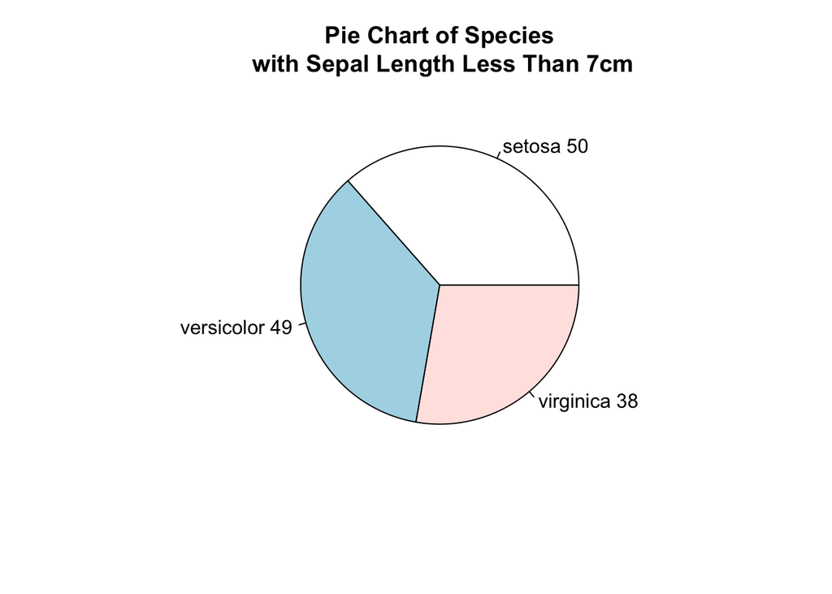

```r
newSepalLength <- subset(iris, iris$Sepal.Length <7)
newTable <- table(newSepalLength$Species)
newLabel <- paste(names(newTable), newTable)
pie(main="Pie Chart of Species\n with Sepal Length Less Than 7cm", newTable, labels = newLabel)
```

END of Assignment #1.